# Stats102A_HW1

Yufei Li

1/20/2020

## Question 1

1. Create a structured flowchart of the algorithm.

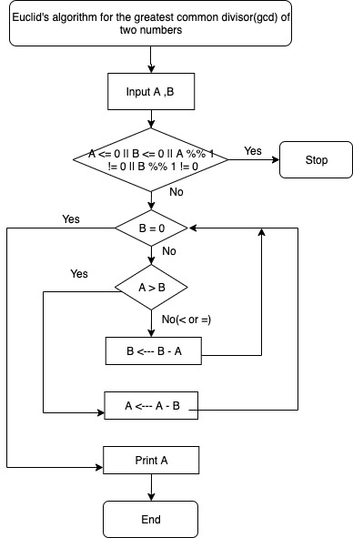

2. Write pseudocode sufficiently complete, clear, and concise enough to enable a person to accurately implement the algorithm in any programming language they are adept with using.

Pseudocode for `gcd` function:

```r
FUNCTION: gcd
INPUTS: integer x, integer y
OUTPUT: greatest common divisor (GCD) between x and y

IF x <= 0 OR y <= 0 OR x %% 1 != 0 OR y %% 1 != 0
  stop processing and print message require positive integer arguments for GCD computation
ELSE
  WHILE y > 0
    temp <- y (assign y to a temporary integer temp)
    y <- x %% y (assign reminder of x mode by y to y)
    x <- temp (assign temp to x)
  ENDWHILE
  PRINT x as final result as GCD
ENDIF
```

Pseudocode for `gcd_3` function:

```r
FUNCTION: gcd_3
INPUTS: integer x, integer y, integer z
OUTPUT: greatest common divisor (GCD) between x, y and z

Leverage function gcd, first find GCD between y and z by
temp_result <- gcd(y, z)
then find GCD between x and temp_result by
final_result <- gcd(x, temp_result)
The final_result is the GCD between x, y and z
PRINT final_result
```

3. Please write a function, gcd(), which takes two positive integers a, b and calculates their greatest common divisor (GCD) using the Euclidean algorithm.

```r
gcd <- function(x, y) {
  if(x <= 0 || y <= 0 || x %% 1 != 0 || y %% 1 != 0) {
    # Check if given number match the positive requirement
    stop("Please provide positive integer arguments for GCD computation")
  } else {
    # Implement Euclidean Algorithm
    while(y) {
      temp <- y
      y <- x %% y
      x <- temp
    }
    x
  }
}
```

Based on your gcd(), please write another function, which takes three positive integers and returns their GCD.

```r
gcd_3 <- function(x, y, z) {
  # Use gcd function
  gcd(x, gcd(y, z))
}
```

## Question 2

1. Create a structured flowchart of the algorithm.

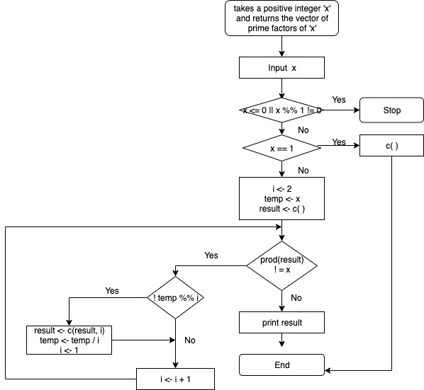

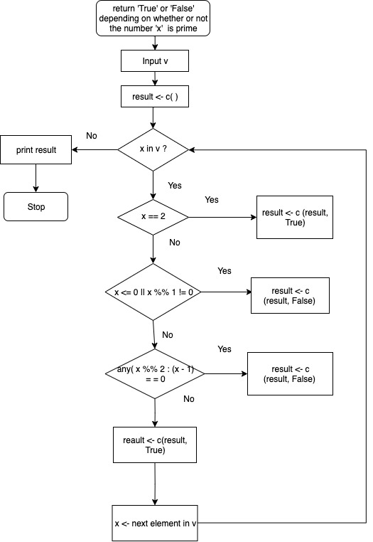

2. Write pseudocode sufficiently complete, clear, and concise enough to enable a person to accurately implement the algorithm in any programming language they are adept with using.  
   Pseudocode for `get_factors` function:

```r
FUNCTION: get_factors
INPUTS: integer x
OUTPUT: vector of prime factors for x

IF x <= 0 OR x %% 1 != 0
  stop processing and print message require positive integer arguments for GCD computation
ELSE IF x == 1
  OUTPUT empty vector as result
ELSE
  i <- 2 (Prime number start from 2)
  temp <- x (assign x to temporary integer temp)
  create empty vector as result
  WHILE the production from vector result != given integer x
    IF reminder of temp divided by i == 0
      append i to the result vector
      temp <- temp / i (divide temp by i)
      i <- 1 (reset i to 1)
    ENDIF
    i <- i + 1 (increase i by 1)
  ENDWHILE
  OUTPUT vector result
ENDIF
```

Pseudocode for `is_prime` function:

```r
FUNCTION: is_prime
INPUTS: vector v
OUTPUT: TRUE or FALSE

Create empty vector as result
FOR each element as x in vector v
  IF x == 2
    append TRUE on vector result
  ELSE IF x <= 0 OR x %% 1 != 0
    append FALSE on vector result
  ELSE IF find any integer between 2 to (x - 1) able to mode x as result 0 means not prime number
      append FALSE on vector result
  ELSE
      append TRUE on vector result
  ENDIF
ENDFOR
OUTPUT vector result
```

c1) Please write a function `get_factors()` which takes a positive integer `x` and returns the vector of (not necessarily unique) prime factors of `x`.  
The `get_factors()` function is below:

```r
get_factors <- function(x) {
  if(x <= 0 || x %% 1 != 0) {
    # Check if given number match the positive integer requirement
    stop("Please provide positive integer argument for get factors computation")
  } else if(x == 1) {
    # 1 not have prime factor
    c()
  } else {
    # Prime number start from 2
    i <- 2
    temp <- x
    result <- c()
    # Looply check until the production equals given number
    while(prod(result) != x) {
      if(!temp %% i) {
        result <- c(result, i)
        temp <- temp / i;
        i <- 1
      }
      i <- i + 1
    }
    result
  }
}
```

c2) In addition, write at least one “helper function”, `is_prime()` which returns `TRUE` or `FALSE` depending on whether or not the number `x` is prime.  
The `is_prime()` function is below:

```r
is_prime <- function(v) {
  result <- c()
  for(x in v) {
    # 2 is prime number
    if(x == 2) {
      result <- c(result, TRUE)
      # If any number not positive integer
    } else if(x <= 0 || x %% 1 != 0) {
      result <- c(result, FALSE)
      # If any number between 2 to (x - 1) able to divide x, x not prime
    } else if(any(x %% 2:(x - 1) == 0)) {
      result <- c(result, FALSE)
    } else {
      result <- c(result, TRUE)
    }
  }
  result
}
```

c3)Testing result with given code, the result should always `TRUE`:

```r
x <- sample(x = 1e4, size = 1)
y <- get_factors(x)
this_works <- prod(y) == x & all(is_prime(y))
this_works
```

```
## [1] TRUE
```

No matter how many times running the test, `this_works` always keep as `TRUE` as expected.